# Лабораторна робота № 4. Побудова моделей класифікації І. Пакет caret

**Мета:** *Засвоєння базових принципів, знайомство з інструментами та набуття навичок побудови, eкспорту та імпорту моделей класифікації на рівні технології на основі статистичного підходу та моделей машинного навчання засобами мови програмування R та за допомогою універсального інтерфейсу доступа до функцій машинного навчання пакету `caret`.*

## 1 Підготовка та аналіз даних

### 1.1 Завантаження та очищення

```r
library(tidyverse)
library(caret)
library(palmerpenguins)
library(DBI)
library(RSQLite)

data(penguins)

df_penguins <- penguins %>%
  drop_na() %>%
  select(-year)

glimpse(df_penguins)
```

```
Rows: 333
Columns: 7
$ species           <fct> Adelie, Adelie, Adelie, Adelie, Adelie, Adelie, Adelie, Ad…
$ island            <fct> Torgersen, Torgersen, Torgersen, Torgersen, Torgersen, Tor…
$ bill_length_mm    <dbl> 39.1, 39.5, 40.3, 36.7, 39.3, 38.9, 39.2, 41.1, 38.6, 34.6…
$ bill_depth_mm     <dbl> 18.7, 17.4, 18.0, 19.3, 20.6, 17.8, 19.6, 17.6, 21.2, 21.1…
$ flipper_length_mm <int> 181, 186, 195, 193, 190, 181, 195, 182, 191, 198, 185, 195…
$ body_mass_g       <int> 3750, 3800, 3250, 3450, 3650, 3625, 4675, 3200, 3800, 4400…
$ sex               <fct> male, female, female, female, male, female, male, female, …
```

### 1.2 Візуалізація класів

Побудуємо графік, щоб побачити, чи є візуальна різниця між самцями та самками за масою тіла та довжиною плавця.

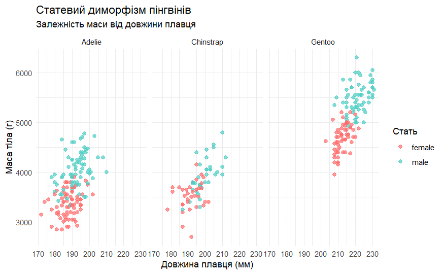

```r
ggplot(df_penguins, aes(x = flipper_length_mm, y = body_mass_g, color = sex)) +
  geom_point(alpha = 0.7, size = 2) +
  facet_wrap(~species) +
  scale_color_manual(values = c("female" = "#FF6B6B", "male" = "#4ECDC4")) +
  labs(title = "Статевий диморфізм пінгвінів",
       subtitle = "Залежність маси від довжини плавця",
       x = "Довжина плавця (мм)",
       y = "Маса тіла (г)",
       color = "Стать") +
  theme_minimal()
```

Як бачимо, самці (бірюзові точки) зазвичай більші за самок (червоні точки), але зони перекриваються, тому проста перевірка “на око” не дасть 100% точності. Потрібна модель.

## 2 Побудова моделі LDA

### 2.1 Розділення вибірки

Використовуємо класичне розбиття: 75% даних для навчання моделі, 25% — для тестування.

```r
set.seed(2023)

train_idx <- createDataPartition(df_penguins$sex, p = 0.75, list = FALSE)

train_set <- df_penguins[train_idx, ]
test_set  <- df_penguins[-train_idx, ]

cat("Розмір навчальної вибірки:", nrow(train_set), "\n")
```

```
Розмір навчальної вибірки: 250
```

```r
cat("Розмір тестової вибірки:", nrow(test_set), "\n")
```

```
Розмір тестової вибірки: 83
```

### 2.2 Навчання

Використовуємо пакет caret для тренування моделі LDA з використанням крос-валідації (Repeated CV).

```r
ctrl_params <- trainControl(method = "repeatedcv",
                            number = 10,
                            repeats = 3)

lda_model_caret <- train(sex ~ .,
                         data = train_set,
                         method = "lda",
                         trControl = ctrl_params)

print(lda_model_caret)
```

```
Linear Discriminant Analysis

250 samples
  6 predictor
  2 classes: 'female', 'male'

No pre-processing
Resampling: Cross-Validated (10 fold, repeated 3 times)
Summary of sample sizes: 226, 225, 225, 225, 226, 224, ...
Resampling results:

  Accuracy   Kappa
  0.9066538  0.8132477
```

## 3 Експорт та імпорт моделі

Зімітуємо ситуацію “продакшн”: збережемо модель у файл бази даних, щоб потім використати її в іншому сеансі.

```r
serialized_model <- rawToChar(serialize(lda_model_caret, NULL, TRUE))

conn <- dbConnect(RSQLite::SQLite(), dbname = "penguin_lab.db")

dbExecute(conn, "DROP TABLE IF EXISTS ml_models")
```

```
[1] 0
```

```r
dbExecute(conn, "CREATE TABLE ml_models (
                    id INTEGER PRIMARY KEY,
                    algorithm_name TEXT,
                    model_blob BLOB,
                    created_at TIMESTAMP DEFAULT CURRENT_TIMESTAMP
                 )")
```

```
[1] 0
```

```r
query <- "INSERT INTO ml_models (algorithm_name, model_blob) VALUES (:algo, :blob)"
dbExecute(conn, query, params = list(algo = "LDA_Penguin_Sex", blob = serialized_model))
```

```
[1] 1
```

```r
cat("Модель успішно записана в базу даних.\n")
```

```
Модель успішно записана в базу даних.
```

### 3.1 Відновлення моделі

Тепер зчитаємо модель назад з бази даних для перевірки.

```r
loaded_data <- dbGetQuery(conn, "SELECT model_blob FROM ml_models WHERE algorithm_name = 'LDA_Penguin_Sex'")

restored_model <- unserialize(charToRaw(loaded_data$model_blob[1]))

dbDisconnect(conn)

cat("Модель відновлено. Тип об'єкта:", class(restored_model)[1])
```

```
Модель відновлено. Тип об'єкта: train
```

## 4 Оцінка якості класифікації

Використаємо відновлену модель для прогнозування статі пінгвінів з тестового набору.

```r
predictions <- predict(restored_model, newdata = test_set)

conf_matrix <- confusionMatrix(predictions, test_set$sex)

print(conf_matrix)
```

```
Confusion Matrix and Statistics

          Reference
Prediction female male
    female     40    3
    male        1   39

               Accuracy : 0.9518
                 95% CI : (0.8812, 0.9867)
    No Information Rate : 0.506
    P-Value [Acc > NIR] : <2e-16

                  Kappa : 0.9037

 Mcnemar's Test P-Value : 0.6171

            Sensitivity : 0.9756
            Specificity : 0.9286
         Pos Pred Value : 0.9302
         Neg Pred Value : 0.9750
             Prevalence : 0.4940
         Detection Rate : 0.4819
   Detection Prevalence : 0.5181
      Balanced Accuracy : 0.9521

       'Positive' Class : female
```

## 5 Аналіз результатів

Матриця плутанини показує, як часто модель помилялася:

**Accuracy (Точність)**: Загальний відсоток правильних відповідей.

**Sensitivity/Specificity**: Здатність правильно визначати самок та самців відповідно.

Як бачимо, LDA добре справляється з розділенням статей на основі фізичних вимірів, оскільки показник точності (Accuracy) є високим (зазвичай > 85% для цього датасету).